# FinalPresentation slides

### Kaggle AMS 2013-2014 Solar Energy Prediction Contest

#### General Assembly Data Science Course Project Washington, DC (11/30/15 - 02/22/16)

#### Joel Piper

[figure not shown]

### Overview of Competition:

- Electric utility companies need accurate forecasts of energy production to balance renewables and fossil fuels
- Errors in the forecast could lead to large expenses for the utility
- The goal of the contest is to discover which statistical and machine learning techniques provide the best short term predictions of solar energy production
- Contestants will predict the total daily incoming solar energy at 98 Oklahoma Mesonet sites, which will serve as "solar farms" for the contest
- Input numerical weather prediction data for the contest comes from the NOAA/ESRL Global Ensemble Forecast System (GEFS) Reforecast Version 2

#### Outputs

- Total energy for each of 5113 days at 98 stations
- Measurements over same 5113 days (1796 days for test set)
- 15 weather-related variables
- 11 "different" models
- 5 measurements each day
- 9x14 latitude/longitude grid of estimates (not co-located with stations!)

**Given Data:**

| Variable | Description | Units |
| --- | --- | --- |
| apcp_sfc | 3-Hour accumulated precipitation at the surface | kg m-2 |
| dlwrf_sfc | Downward long-wave radiative flux average at the surface | W m-2 |
| dswrf_sfc | Downward short-wave radiative flux average at the surface | W m-2 |
| pres_msl | Air pressure at mean sea level | Pa |
| pwat_eatm | Precipitable Water over the entire depth of the atmosphere | kg m-2 |
| spfh_2m | Specific Humidity at 2 m above ground | kg kg-1 |
| tcdc_eatm | Total cloud cover over the entire depth of the atmosphere | % |
| tcolc_eatm | Total column-integrated condensate over the entire atmos. | kg m-2 |
| tmax_2m | Maximum Temperature over the past 3 hours at 2 m above the ground | K |
| tmin_2m | Mininmum Temperature over the past 3 hours at 2 m above the ground | K |
| tmp_2m | Current temperature at 2 m above the ground | K |
| tmp_sfc | Temperature of the surface | K |
| ulwrf_sfc | Upward long-wave radiation at the surface | W m-2 |
| ulwrf_tatm | Upward long-wave radiation at the top of the atmosphere | W m-2 |
| uswrf_sfc | Upward short-wave radiation at the surface | W m-2 |

### A small subset of the total solar data (y_train)

```python
import pandas as pd
import netCDF4 as nc
import numpy as np
train_data = pd.read_csv('../../solar/data/kaggle_solar/train.csv', index_col='Date', parse_dates=['Date'])
train_data.head(5).iloc[:,0:13]
```

| Date | ACME | ADAX | ALTU | APAC | ARNE | BEAV | BESS | BIXB | BLAC | BOIS | BOWL | BREC | BRIS |
| --- | --- | --- | --- | --- | --- | --- | --- | --- | --- | --- | --- | --- | --- |
| 1994-01-01 | 12384900 | 11930700 | 12116700 | 12301200 | 10706100 | 10116900 | 11487900 | 11182800 | 10848300 | 10225200 | 11374200 | 10335300 | 11119200 |
| 1994-01-02 | 11908500 | 9778500 | 10862700 | 11666400 | 8062500 | 9262800 | 9235200 | 3963300 | 3318300 | 11316600 | 8318700 | 4711500 | 5530500 |
| 1994-01-03 | 12470700 | 9771900 | 12627300 | 12782700 | 11618400 | 10789800 | 11895900 | 4512600 | 5266500 | 11916000 | 8594700 | 7239600 | 5596200 |
| 1994-01-04 | 12725400 | 6466800 | 13065300 | 12817500 | 12134400 | 11816700 | 12186600 | 3212700 | 8270100 | 11884200 | 5754900 | 8842500 | 4360500 |
| 1994-01-05 | 10894800 | 11545200 | 8060400 | 10379400 | 6918600 | 9936300 | 6411300 | 9566100 | 8009400 | 9288900 | 10971000 | 8810100 | 10572300 |

### A small subset of the input weather data (X_train)

```python
dswrf = nc.Dataset('../../solar/data/kaggle_solar/train/dswrf_sfc_latlon_subset_19940101_20071231.nc','r+').variables.values()[-1]
subset = dswrf[0:3,2:4,2:5,2:4,2:4]
nc_var = pd.DataFrame(np.reshape(subset,(np.shape(subset)[0], np.product(np.shape(subset)[1:]))))
nc_var
```

|  | 0 | 1 | 2 | 3 | 4 | 5 | 6 | 7 | 8 | 9 | ... | 14 | 15 | 16 | 17 | 18 | 19 | 20 | 21 | 22 | 23 |
| --- | --- | --- | --- | --- | --- | --- | --- | --- | --- | --- | --- | --- | --- | --- | --- | --- | --- | --- | --- | --- | --- |
| 0 | 200 | 210 | 190 | 200 | 580 | 570 | 560 | 540 | 410 | 400 | ... | 190 | 200 | 580 | 580 | 570 | 570 | 420 | 410 | 400 | 400 |
| 1 | 210 | 210 | 200 | 200 | 600 | 600 | 580 | 580 | 430 | 420 | ... | 200 | 200 | 600 | 600 | 580 | 580 | 430 | 420 | 420 | 410 |
| 2 | 200 | 210 | 190 | 200 | 590 | 590 | 570 | 570 | 420 | 420 | ... | 190 | 200 | 580 | 580 | 570 | 570 | 420 | 410 | 410 | 400 |

3 rows × 24 columns

### A small subset of the input weather data (X_train), cont.

```python
dswrf_with_index
```

| train_dates | models | times | lats | lons | dwsrf_sfc |
| --- | --- | --- | --- | --- | --- |
| 1994-01-01 | 2 | 18 | 36 | 256 | 200 |
|  |  |  |  | 257 | 210 |
|  |  |  | 37 | 256 | 190 |
|  |  |  |  | 257 | 200 |
|  |  | 21 | 36 | 256 | 580 |
|  |  |  |  | 257 | 570 |
|  |  |  | 37 | 256 | 560 |
|  |  |  |  | 257 | 540 |
|  |  | 24 | 36 | 256 | 410 |
|  |  |  |  | 257 | 400 |
|  |  |  | 37 | 256 | 400 |
|  |  |  |  | 257 | 390 |
|  | 3 | 18 | 36 | 256 | 200 |
|  |  |  |  | 257 | 210 |
|  |  |  | 37 | 256 | 190 |
|  |  |  |  | 257 | 200 |
|  |  | 21 | 36 | 256 | 580 |
|  |  |  |  | 257 | 580 |
|  |  |  | 37 | 256 | 570 |
|  |  |  |  | 257 | 570 |
|  |  | 24 | 36 | 256 | 420 |
|  |  |  |  | 257 | 410 |
|  |  |  | 37 | 256 | 400 |
|  |  |  |  | 257 | 400 |
| 1994-01-02 | 2 | 18 | 36 | 256 | 210 |
|  |  |  |  | 257 | 210 |
|  |  |  | 37 | 256 | 200 |
|  |  |  |  | 257 | 200 |
|  |  | 21 | 36 | 256 | 600 |
|  |  |  |  | 257 | 600 |
|  | 2 | 21 | 36 | ... | ... |
|  | 3 | 21 | 37 | 256 | 580 |
|  |  |  |  | 257 | 580 |
|  |  | 24 | 36 | 256 | 430 |
|  |  |  |  | 257 | 420 |
|  |  |  | 37 | 256 | 420 |
|  |  |  |  | 257 | 410 |
| 1994-01-03 | 2 | 18 | 36 | 256 | 200 |
|  |  |  |  | 257 | 210 |
|  |  |  | 37 | 256 | 190 |
|  |  |  |  | 257 | 200 |
|  |  | 21 | 36 | 256 | 590 |
|  |  |  |  | 257 | 590 |
|  |  |  | 37 | 256 | 570 |
|  |  |  |  | 257 | 570 |
|  |  | 24 | 36 | 256 | 420 |
|  |  |  |  | 257 | 420 |
|  |  |  | 37 | 256 | 410 |
|  |  |  |  | 257 | 400 |
|  | 3 | 18 | 36 | 256 | 200 |
|  |  |  |  | 257 | 210 |
|  |  |  | 37 | 256 | 190 |
|  |  |  |  | 257 | 200 |
|  |  | 21 | 36 | 256 | 580 |
|  |  |  |  | 257 | 580 |
|  |  |  | 37 | 256 | 570 |
|  |  |  |  | 257 | 570 |
|  |  | 24 | 36 | 256 | 420 |
|  |  |  |  | 257 | 410 |
|  |  |  | 37 | 256 | 410 |
|  |  |  |  | 257 | 400 |

72 rows × 1 columns

## Exploration of the input weather variables

[figure not shown]

## Exploration of the Output (Total Solar Energy)

[figure not shown]

## Feature Engineering

```python
input_data[0].iloc[0:10,range(0,7)+range(47,51)]
```

| train_dates | models var lat_longs times station | values 0 dswrf_sfc 1_SE 21 | values 0 uswrf_sfc 1_SE 21 | values 0 tcolc_eatm 1_SE 21 | values 0 spfh_2m 1_SE 21 | values 0 dswrf_sfc 2_SW 21 | values 0 uswrf_sfc 2_SW 21 | values 0 tcolc_eatm 2_SW 21 | values 1 spfh_2m 4_NW 21 | values 1 dswrf_sfc 1_SE 24 | values 1 uswrf_sfc 1_SE 24 | values 1 tcolc_eatm 1_SE 24 |
| --- | --- | --- | --- | --- | --- | --- | --- | --- | --- | --- | --- | --- |
| 1994-01-01 | ACME | 540 | 115 | 0.0014 | 0.00352 | 530 | 110 | 0 | 0.00367 | 360 | 81 | 0.0259 |
|  | BEAV | 520 | 122 | 0.0009 | 0.00232 | 510 | 118 | 0.0014 | 0.00307 | 350 | 84 | 0.0056 |
| 1994-01-02 | ACME | 530 | 112 | 0.0116 | 0.00376 | 500 | 100 | 0.01 | 0.00443 | 350 | 78 | 0.0006 |
|  | BEAV | 510 | 122 | 0.0037 | 0.00242 | 460 | 102 | 0.0013 | 0.00256 | 350 | 87 | 0.0015 |
| 1994-01-03 | ACME | 550 | 118 | 0.0002 | 0.00288237 | 550 | 114 | 0.003 | 0.00261 | 370 | 83 | 0 |
|  | BEAV | 520 | 124 | 0.0003 | 0.00229237 | 520 | 119 | 0.004 | 0.00252 | 350 | 87 | 0 |
| 1994-01-04 | ACME | 560 | 120 | 0 | 0.00269 | 550 | 114 | 0.0003 | 0.0026683 | 370 | 85 | 0.0001 |
|  | BEAV | 530 | 127 | 0.0021 | 0.00167 | 530 | 123 | 0.0043 | 0.0021783 | 360 | 91 | 0.0022 |
| 1994-01-05 | ACME | 540 | 115 | 0.0327 | 0.00334 | 540 | 112 | 0.0094 | 0.00374 | 340 | 72 | 0.0323 |
|  | BEAV | 430 | 94 | 0.071 | 0.00171 | 460 | 99 | 0.1407 | 0.00267 | 300 | 69 | 0.0038 |

```python
my_input[0].iloc[90:110,0:4]
```

| train_dates | station | (frac_dist, lat_dist) | (frac_dist, long_dist) | (days_from_coldest, from_coldest) | (days_from_solstice, from_solstice) |
| --- | --- | --- | --- | --- | --- |
| 2000-01-01 | WATO | 0.84185 | 0.47385 | 3 | 11 |
|  | WAUR | 0.16775 | 0.01185 | 3 | 11 |
|  | WEAT | 0.50830 | 0.22491 | 3 | 11 |
|  | WEST | 0.01100 | 0.35504 | 3 | 11 |
|  | WILB | 0.90092 | 0.65195 | 3 | 11 |
|  | WIST | 0.98426 | 0.31222 | 3 | 11 |
|  | WOOD | 0.42329 | 0.58318 | 3 | 11 |
|  | WYNO | 0.51806 | 0.65778 | 3 | 11 |
| 2000-01-02 | ACME | 0.80833 | 0.97675 | 2 | 12 |
|  | ADAX | 0.79851 | 0.33091 | 2 | 12 |
|  | ALTU | 0.58722 | 0.66192 | 2 | 12 |
|  | APAC | 0.91418 | 0.70784 | 2 | 12 |
|  | ARNE | 0.07204 | 0.09692 | 2 | 12 |
|  | BEAV | 0.80253 | 0.46988 | 2 | 12 |
|  | BESS | 0.40185 | 0.94153 | 2 | 12 |
|  | BIXB | 0.96305 | 0.13379 | 2 | 12 |
|  | BLAC | 0.75443 | 0.74548 | 2 | 12 |
|  | BOIS | 0.69256 | 0.50287 | 2 | 12 |
|  | BOWL | 0.17156 | 0.36879 | 2 | 12 |
|  | BREC | 0.41201 | 0.30606 | 2 | 12 |

```python
my_input[0].iloc[0:10,604:613]
```

| train_dates | station | stat_ACME | stat_ADAX | stat_ALTU | stat_APAC | stat_ARNE | stat_BEAV | stat_BESS | stat_BIXB | stat_BLAC |
| --- | --- | --- | --- | --- | --- | --- | --- | --- | --- | --- |
| 2000-01-01 | ACME | 1 | 0 | 0 | 0 | 0 | 0 | 0 | 0 | 0 |
|  | ADAX | 0 | 1 | 0 | 0 | 0 | 0 | 0 | 0 | 0 |
|  | ALTU | 0 | 0 | 1 | 0 | 0 | 0 | 0 | 0 | 0 |
|  | APAC | 0 | 0 | 0 | 1 | 0 | 0 | 0 | 0 | 0 |
|  | ARNE | 0 | 0 | 0 | 0 | 1 | 0 | 0 | 0 | 0 |
|  | BEAV | 0 | 0 | 0 | 0 | 0 | 1 | 0 | 0 | 0 |
|  | BESS | 0 | 0 | 0 | 0 | 0 | 0 | 1 | 0 | 0 |
|  | BIXB | 0 | 0 | 0 | 0 | 0 | 0 | 0 | 1 | 0 |
|  | BLAC | 0 | 0 | 0 | 0 | 0 | 0 | 0 | 0 | 1 |
|  | BOIS | 0 | 0 | 0 | 0 | 0 | 0 | 0 | 0 | 0 |

## Model Selection

- Linear Regression
- Ridge Regression
- Lasso Regression
- Decision Tree Regressor
- Random Forest Regressor
- Gradient Boosting Regressor

#### Mean Absolute Error (1/1/2000 - 6/30/2000)

| Method | Error |
| --- | --- |
| Average Value Over Each Station | 6.6M |
| Linear Regression | 3.3M |
| Ridge Regression | 2.8M |
| Decision Tree | 3.6M |

[figure not shown]

## Variable Importance

| Rank | Variable | Description | Time (UTC-6:00)/(UTC-5:00, DST) | Location | Model |
| --- | --- | --- | --- | --- | --- |
| 1 | dswrf_sfc | Downward short-wave radiative flux average at the surface | 21:00 | SW | 1 |
| 2 | dswrf_sfc | Downward short-wave radiative flux average at the surface | 24:00 | NW | 0 |
| 3 | stat_ketc | Is the station KETC? | NA | NA | NA |
| 4 | days_from_solstice | Number of days from the shortest day of the year | NA | NA | NA |
| 5 | dswrf_sfc | Downward short-wave radiative flux average at the surface | 21:00 | NW | 0 |
| 6 | tcolc_eatm | Total column-integrated condensate over the entire atmos. | 21:00 | SW | 0 |
| 7 | ulwrf_tatm | Upward long-wave radiation at the top of the atmosphere | 24:00 | NW | 0 |
| 8 | dswrf_sfc | Downward short-wave radiative flux average at the surface | 18:00 | SW | 0 |
| 9 | spfh_2m | Specific Humidity at 2 m above ground | 12:00 | SW | 1 |
| 10 | dswrf_sfc | Downward short-wave radiative flux average at the surface | 21:00 | SE | 1 |

```python
pd.DataFrame(corr_data.corr().ix[:,['dswrf_sfc', 'ulwrf_tatm', 'tcolc_eatm', 'total_solar']])
```

|  | dswrf_sfc | ulwrf_tatm | tcolc_eatm | total_solar |
| --- | --- | --- | --- | --- |
| dswrf_sfc | 1.000000 | 0.609336 | -0.404502 | 0.786436 |
| dlwrf_sfc | 0.275821 | 0.042220 | 0.267159 | 0.072633 |
| uswrf_sfc | 0.853867 | 0.568324 | -0.438247 | 0.723475 |
| ulwrf_sfc | 0.683873 | 0.413187 | -0.056352 | 0.494502 |
| ulwrf_tatm | 0.609336 | 1.000000 | -0.566786 | 0.569132 |
| pwat_eatm | 0.205423 | -0.068035 | 0.295510 | -0.035836 |
| tcdc_eatm | -0.404612 | -0.566111 | 0.999866 | -0.382592 |
| apcp_sfc | -0.310501 | -0.389774 | 0.566891 | -0.278272 |
| pres_msl | -0.334547 | -0.250148 | 0.012343 | -0.197308 |
| spfh_2m | 0.412424 | 0.169216 | 0.129966 | 0.169196 |
| tcolc_eatm | -0.404502 | -0.566786 | 1.000000 | -0.382638 |
| tmax_2m | 0.701841 | 0.440850 | -0.110414 | 0.527397 |
| tmin_2m | 0.505299 | 0.294678 | 0.057793 | 0.328832 |
| tmp_2m | 0.706795 | 0.444582 | -0.121598 | 0.532404 |
| tmp_sfc | 0.738276 | 0.502043 | -0.231571 | 0.592087 |
| total_solar | 0.786436 | 0.569132 | -0.382638 | 1.000000 |

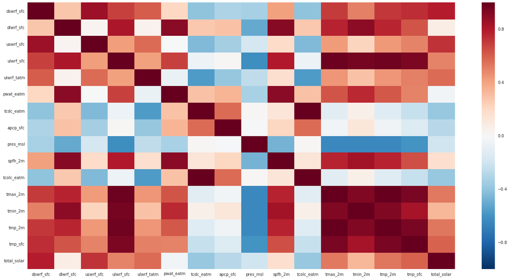

```python
plt.figure(figsize=(24, 12))
sns.heatmap(corr_data.corr())
```

## Infrastructure

[figure not shown]

## Lessons Learned

- Logging-- worth careful consideration about what to include
- Testing-- easy to throw notebook checks into a function
- Size-- memory limits are easy to hit; design from the start for big data; single pickle file will not scale
- Evaluation-- gained considerable insight on project over past three days; fun to push bigger, faster models, but it is worthwhile to spend some time reflecting on design
- Kaggle-- winning models in this competition used very little feature engineering and focused on sophisticated modeling methodologies

## Ideas for Improvement

- Ramp up AWS use and overhaul design to make use of Apache Spark
- Examine more sophisticated data access and storage methods
- Focus automation efforts on testing and tuning of models and hyperparameters
- Visualize the comparative performance of various models more thoroughly
- Revisit exploratory analysis to identify patterns that lead to poor model performance
- Build out more rigorous testing scripts